# NYC squirrels (with solutions)

Ina Bornkessel-Schlesewsky

Jan 2021 (updated: 2021-02-02)

## Import data and rename variables

Import and inspect the data. Note the different options for inspecting the data.

```r
squirrels <- read_csv("data/2018_Central_Park_Squirrel_Census_-_Squirrel_Data.csv")
# show the data
# don't forget that you can also use view(squirrels) to do this
squirrels
```

```
## # A tibble: 3,023 x 36
##        X     Y `Unique Squirre… Hectare Shift   Date `Hectare Squirr… Age
##    <dbl> <dbl> <chr>            <chr>   <chr>  <dbl>            <dbl> <chr>
##  1 -74.0  40.8 37F-PM-1014-03   37F     PM    1.01e7                3 <NA>
##  2 -74.0  40.8 37E-PM-1006-03   37E     PM    1.01e7                3 Adult
##  3 -74.0  40.8 2E-AM-1010-03    02E     AM    1.01e7                3 Adult
##  4 -74.0  40.8 5D-PM-1018-05    05D     PM    1.02e7                5 Juve…
##  5 -74.0  40.8 39B-AM-1018-01   39B     AM    1.02e7                1 <NA>
##  6 -74.0  40.8 33H-AM-1019-02   33H     AM    1.02e7                2 Juve…
##  7 -74.0  40.8 6G-PM-1020-02    06G     PM    1.02e7                2 Adult
##  8 -74.0  40.8 35C-PM-1013-03   35C     PM    1.01e7                3 <NA>
##  9 -74.0  40.8 7B-AM-1008-09    07B     AM    1.01e7                9 Adult
## 10 -74.0  40.8 32E-PM-1017-14   32E     PM    1.02e7               14 Adult
## # … with 3,013 more rows, and 28 more variables: `Primary Fur Color` <chr>,
## #   `Highlight Fur Color` <chr>, `Combination of Primary and Highlight
## #   Color` <chr>, `Color notes` <chr>, Location <chr>, `Above Ground Sighter
## #   Measurement` <chr>, `Specific Location` <chr>, Running <lgl>,
## #   Chasing <lgl>, Climbing <lgl>, Eating <lgl>, Foraging <lgl>, `Other
## #   Activities` <chr>, Kuks <lgl>, Quaas <lgl>, Moans <lgl>, `Tail
## #   flags` <lgl>, `Tail twitches` <lgl>, Approaches <lgl>, Indifferent <lgl>,
## #   `Runs from` <lgl>, `Other Interactions` <chr>, `Lat/Long` <chr>, `Zip
## #   Codes` <dbl>, `Community Districts` <dbl>, `Borough Boundaries` <dbl>,
## #   `City Council Districts` <dbl>, `Police Precincts` <dbl>
```

```r
# glimpse is another option -- it is useful in cases like this, where we have many columns
glimpse(squirrels)
```

```
## Rows: 3,023
## Columns: 36
## $ X                                            <dbl> -73.95613, -73.95704, -7…
## $ Y                                            <dbl> 40.79408, 40.79485, 40.7…
## $ `Unique Squirrel ID`                         <chr> "37F-PM-1014-03", "37E-P…
## $ Hectare                                      <chr> "37F", "37E", "02E", "05…
## $ Shift                                        <chr> "PM", "PM", "AM", "PM", …
## $ Date                                         <dbl> 10142018, 10062018, 1010…
## $ `Hectare Squirrel Number`                    <dbl> 3, 3, 3, 5, 1, 2, 2, 3, …
## $ Age                                          <chr> NA, "Adult", "Adult", "J…
## $ `Primary Fur Color`                          <chr> NA, "Gray", "Cinnamon", …
## $ `Highlight Fur Color`                        <chr> NA, "Cinnamon", NA, NA, …
## $ `Combination of Primary and Highlight Color` <chr> "+", "Gray+Cinnamon", "C…
## $ `Color notes`                                <chr> NA, NA, NA, NA, NA, NA, …
## $ Location                                     <chr> NA, "Ground Plane", "Abo…
```

[output cut: 23 more lines]

```r
# use the summary function from baseR
summary(squirrels)
```

```
##        X                Y         Unique Squirrel ID   Hectare
##  Min.   :-73.98   Min.   :40.76   Length:3023        Length:3023
##  1st Qu.:-73.97   1st Qu.:40.77   Class :character   Class :character
##  Median :-73.97   Median :40.78   Mode  :character   Mode  :character
##  Mean   :-73.97   Mean   :40.78
##  3rd Qu.:-73.96   3rd Qu.:40.79
##  Max.   :-73.95   Max.   :40.80
##
##     Shift                Date          Hectare Squirrel Number
##  Length:3023        Min.   :10062018   Min.   : 1.000
##  Class :character   1st Qu.:10082018   1st Qu.: 2.000
##  Mode  :character   Median :10122018   Median : 3.000
##                     Mean   :10119487   Mean   : 4.124
##                     3rd Qu.:10142018   3rd Qu.: 6.000
##                     Max.   :10202018   Max.   :23.000
##
##      Age            Primary Fur Color  Highlight Fur Color
##  Length:3023        Length:3023        Length:3023
##  Class :character   Class :character   Class :character
##  Mode  :character   Mode  :character   Mode  :character
##
##
##
##
##  Combination of Primary and Highlight Color Color notes
##  Length:3023                                Length:3023
##  Class :character                           Class :character
##  Mode  :character                           Mode  :character
##
##
##
##
##    Location         Above Ground Sighter Measurement Specific Location
##  Length:3023        Length:3023                      Length:3023
##  Class :character   Class :character                 Class :character
##  Mode  :character   Mode  :character                 Mode  :character
##
##
##
##
```

[output cut: 33 more lines]

```
##  Min.   :10090   Min.   :11          Min.   :4          Min.   :19.00
##  1st Qu.:12081   1st Qu.:19          1st Qu.:4          1st Qu.:19.00
##  Median :12420   Median :19          Median :4          Median :19.00
##  Mean   :11828   Mean   :19          Mean   :4          Mean   :19.07
##  3rd Qu.:12423   3rd Qu.:19          3rd Qu.:4          3rd Qu.:19.00
##  Max.   :12423   Max.   :23          Max.   :4          Max.   :51.00
##  NA's   :3014
##  Police Precincts
##  Min.   :10
##  1st Qu.:13
##  Median :13
##  Mean   :13
##  3rd Qu.:13
##  Max.   :18
##
```

```r
# skim from the skimr package provides further details
skim(squirrels)
```

Data summary

| Name | squirrels |
| --- | --- |
| Number of rows | 3023 |
| Number of columns | 36 |
| _______________________ |  |
| Column type frequency: |  |
| character | 14 |
| logical | 13 |
| numeric | 9 |
| ________________________ |  |
| Group variables | None |

**Variable type: character**

| skim_variable | n_missing | complete_rate | min | max | empty | n_unique | whitespace |
| --- | --- | --- | --- | --- | --- | --- | --- |
| Unique Squirrel ID | 0 | 1.00 | 13 | 14 | 0 | 3018 | 0 |
| Hectare | 0 | 1.00 | 3 | 3 | 0 | 339 | 0 |
| Shift | 0 | 1.00 | 2 | 2 | 0 | 2 | 0 |
| Age | 121 | 0.96 | 1 | 8 | 0 | 3 | 0 |
| Primary Fur Color | 55 | 0.98 | 4 | 8 | 0 | 3 | 0 |
| Highlight Fur Color | 1086 | 0.64 | 4 | 22 | 0 | 10 | 0 |
| Combination of Primary and Highlight Color | 0 | 1.00 | 1 | 27 | 0 | 22 | 0 |
| Color notes | 2841 | 0.06 | 3 | 153 | 0 | 135 | 0 |
| Location | 64 | 0.98 | 12 | 12 | 0 | 2 | 0 |
| Above Ground Sighter Measurement | 114 | 0.96 | 1 | 5 | 0 | 41 | 0 |
| Specific Location | 2547 | 0.16 | 4 | 102 | 0 | 304 | 0 |
| Other Activities | 2586 | 0.14 | 4 | 132 | 0 | 307 | 0 |
| Other Interactions | 2783 | 0.08 | 2 | 106 | 0 | 197 | 0 |
| Lat/Long | 0 | 1.00 | 38 | 45 | 0 | 3023 | 0 |

**Variable type: logical**

| skim_variable | n_missing | complete_rate | mean | count |
| --- | --- | --- | --- | --- |
| Running | 0 | 1 | 0.24 | FAL: 2293, TRU: 730 |
| Chasing | 0 | 1 | 0.09 | FAL: 2744, TRU: 279 |
| Climbing | 0 | 1 | 0.22 | FAL: 2365, TRU: 658 |
| Eating | 0 | 1 | 0.25 | FAL: 2263, TRU: 760 |
| Foraging | 0 | 1 | 0.47 | FAL: 1588, TRU: 1435 |
| Kuks | 0 | 1 | 0.03 | FAL: 2921, TRU: 102 |
| Quaas | 0 | 1 | 0.02 | FAL: 2973, TRU: 50 |
| Moans | 0 | 1 | 0.00 | FAL: 3020, TRU: 3 |
| Tail flags | 0 | 1 | 0.05 | FAL: 2868, TRU: 155 |
| Tail twitches | 0 | 1 | 0.14 | FAL: 2589, TRU: 434 |
| Approaches | 0 | 1 | 0.06 | FAL: 2845, TRU: 178 |
| Indifferent | 0 | 1 | 0.48 | FAL: 1569, TRU: 1454 |
| Runs from | 0 | 1 | 0.22 | FAL: 2345, TRU: 678 |

**Variable type: numeric**

| skim_variable | n_missing | complete_rate | mean | sd | p0 | p25 | p50 | p75 | p100 | hist |
| --- | --- | --- | --- | --- | --- | --- | --- | --- | --- | --- |
| X | 0 | 1 | -73.97 | 0.01 | -73.98 | -73.97 | -73.97 | -73.96 | -73.95 | ▅▇▅▆▂ |
| Y | 0 | 1 | 40.78 | 0.01 | 40.76 | 40.77 | 40.78 | 40.79 | 40.80 | ▇▇▃▅▆ |
| Date | 0 | 1 | 10119487.40 | 42466.71 | 10062018.00 | 10082018.00 | 10122018.00 | 10142018.00 | 10202018.00 | ▇▂▇▂▃ |
| Hectare Squirrel Number | 0 | 1 | 4.12 | 3.10 | 1.00 | 2.00 | 3.00 | 6.00 | 23.00 | ▇▂▁▁▁ |
| Zip Codes | 3014 | 0 | 11828.22 | 995.98 | 10090.00 | 12081.00 | 12420.00 | 12423.00 | 12423.00 | ▂▁▁▁▇ |
| Community Districts | 0 | 1 | 19.00 | 0.23 | 11.00 | 19.00 | 19.00 | 19.00 | 23.00 | ▁▁▁▇▁ |
| Borough Boundaries | 0 | 1 | 4.00 | 0.00 | 4.00 | 4.00 | 4.00 | 4.00 | 4.00 | ▁▁▇▁▁ |
| City Council Districts | 0 | 1 | 19.07 | 1.35 | 19.00 | 19.00 | 19.00 | 19.00 | 51.00 | ▇▁▁▁▁ |
| Police Precincts | 0 | 1 | 13.00 | 0.22 | 10.00 | 13.00 | 13.00 | 13.00 | 18.00 | ▁▇▁▁▁ |

Rename and select variables.

```r
squirrels <- squirrels %>%
  mutate(Date = mdy(Date)) %>%
  rename(primary_fur_colour = `Primary Fur Color`,
         hectare = Hectare,
         shift = Shift,
         date = Date,
         age = Age) %>%
  select(hectare, shift, date, age, primary_fur_colour)
```

## Explore the data via visualisation

Start by plotting a histogram to examine the distribution of the data. The histogram automatically produces counts; we thus only need to specify the x-axis in our aesthetics.

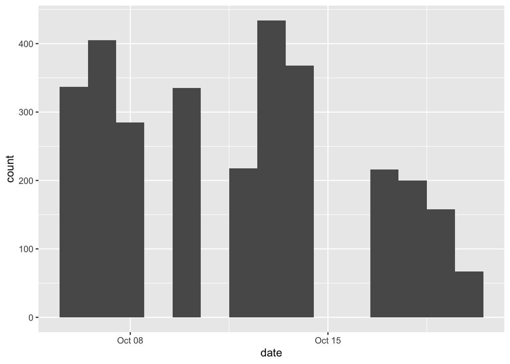

```r
ggplot(data = squirrels, aes(date)) +
  # for histograms, we need to specify the binwidth as the default values may not be optimal
  # since we have a date argument, 1 = one day
  # note that for a time argument, 1 = one second
  geom_histogram(binwidth = 1)
```

Make the x-axis more informative (see https://ggplot2.tidyverse.org/reference/scale_date.html). For these functions, we need the `scales` package.

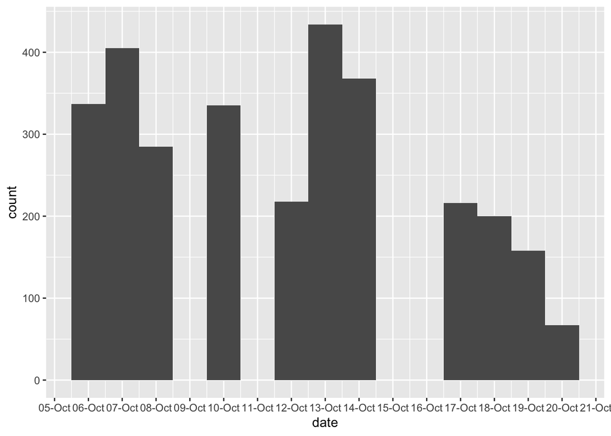

```r
ggplot(squirrels, aes(date)) +
  # since we have a date argument, 1 = one day
  # note that for a time argument, 1 = one second
  geom_histogram(binwidth = 1) +
  scale_x_date(date_breaks = "days" , date_labels = "%d-%b")
```

For an alternative using lines, we can use a frequency polygon (`geom_freqpoly`).

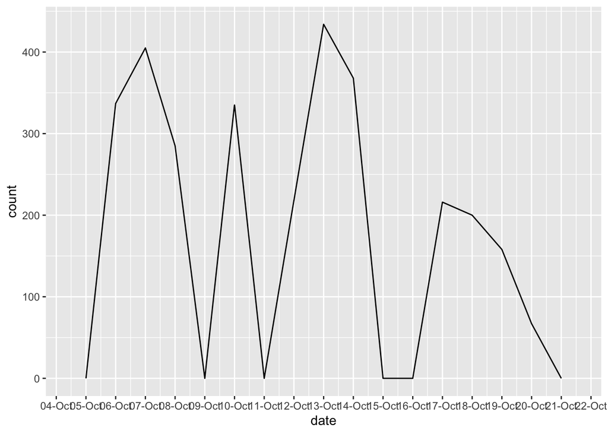

```r
ggplot(squirrels, aes(date)) +
  geom_freqpoly(binwidth = 1) +
  scale_x_date(date_breaks = "days" , date_labels = "%d-%b")
```

Let’s simplify the x-axis given that the month is redundant. At the same time, we can add a few other details to make the plot more self-explanatory.

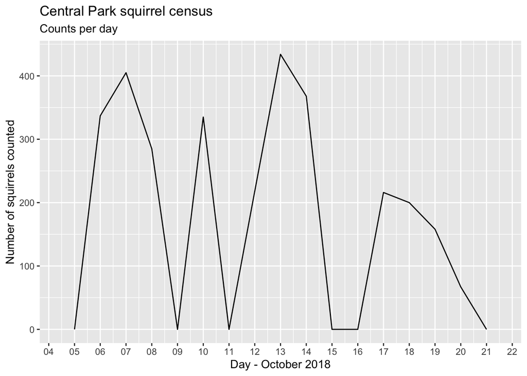

```r
ggplot(squirrels, aes(date)) +
  geom_freqpoly(binwidth = 1) +
  scale_x_date(date_breaks = "days" , date_labels = "%d") +
  xlab("Day - October 2018") +
  ylab ("Number of squirrels counted") +
  ggtitle("Central Park squirrel census", subtitle = "Counts per day")
```

The frequency polygon allows us to start looking at additional variables such as time of sighting (am/pm) …

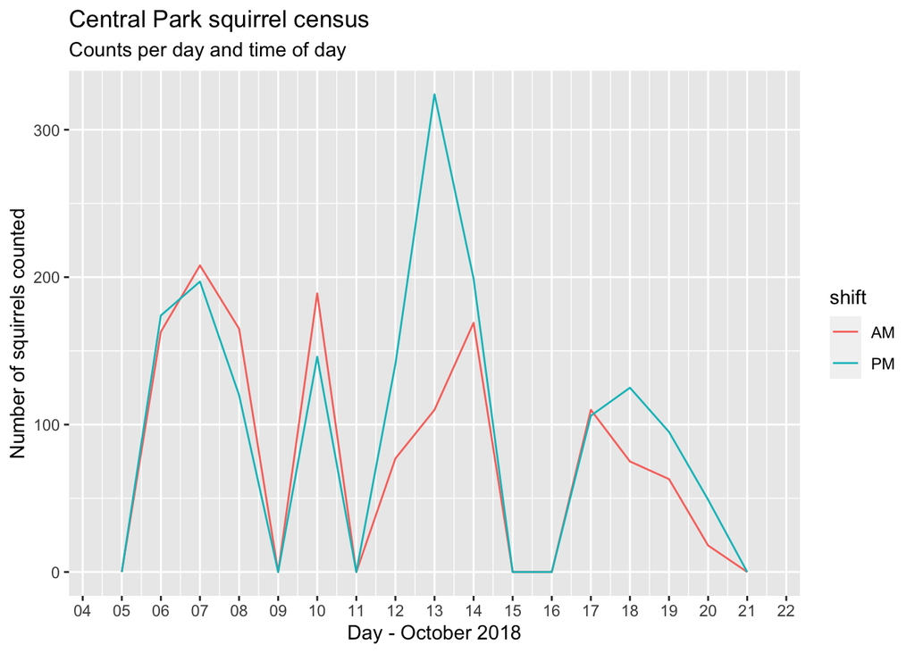

```r
ggplot(squirrels, aes(date)) +
  geom_freqpoly(aes(colour = shift), binwidth = 1) +
  scale_x_date(date_breaks = "days" , date_labels = "%d") +
  xlab("Day - October 2018") +
  ylab ("Number of squirrels counted") +
  ggtitle("Central Park squirrel census", subtitle = "Counts per day and time of day")
```

… or age.

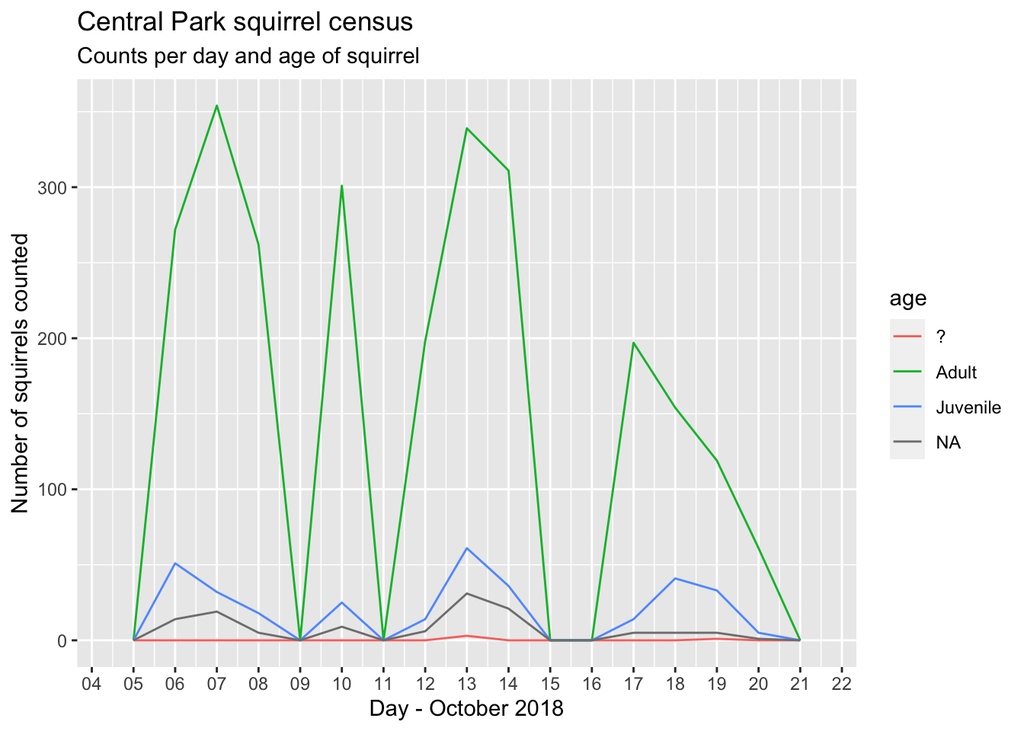

```r
ggplot(squirrels, aes(date)) +
  geom_freqpoly(aes(colour = age), binwidth = 1) +
  scale_x_date(date_breaks = "days" , date_labels = "%d") +
  xlab("Day - October 2018") +
  ylab ("Number of squirrels counted") +
  ggtitle("Central Park squirrel census", subtitle = "Counts per day and age of squirrel")
```

## Why no sightings on certain days?

It seems odd that there are some days without any sightings at all. Could it be the case that the volunteers didn’t go out on certain days? Let’s add day of the week to see if this sheds any light. [This](https://www.rdocumentation.org/packages/base/versions/3.6.2/topics/strptime) is a useful website for how we can specify the axis labels with a date object. (*Note also the syntax for embedding a link to a website in RMarkdown!*) Since month is redundant here anyway, we can drop that easily.

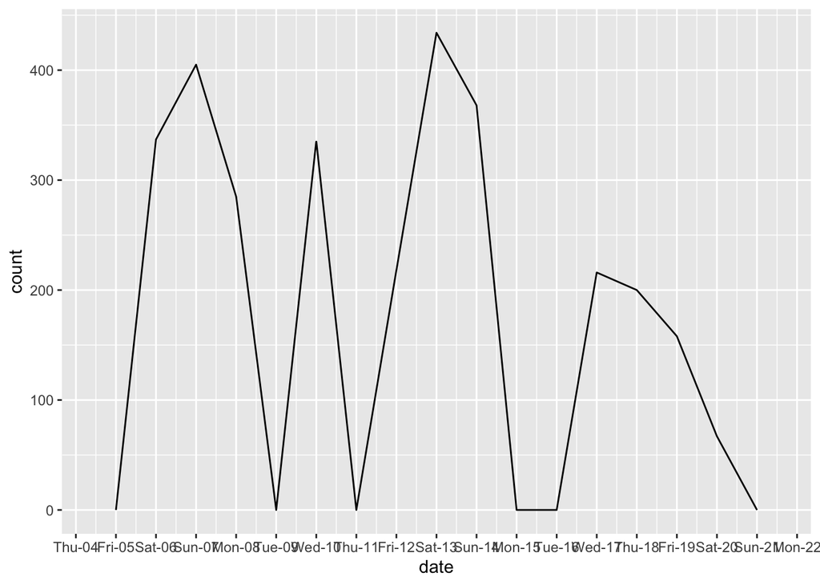

```r
ggplot(squirrels, aes(date)) +
  # since we have a date argument, 1 = one day
  # note that for a time argument, 1 = one second
  geom_freqpoly(binwidth = 1) +
  scale_x_date(date_breaks = "days" , date_labels = "%a-%d")
```

According to this plot, the intermediary counts of 0 occurred on a Tuesday, Thursday, Monday and Tuesday. This seems to render an explanation of volunteers not working a bit less likely.

It also doesn’t seem to be a weather issue as checking weather records from NYC for Oct 2018 (recorded in Central Park!) reveals. Here is a screenshot from [this website](https://www.timeanddate.com/weather/usa/new-york/historic?month=10&year=2018):

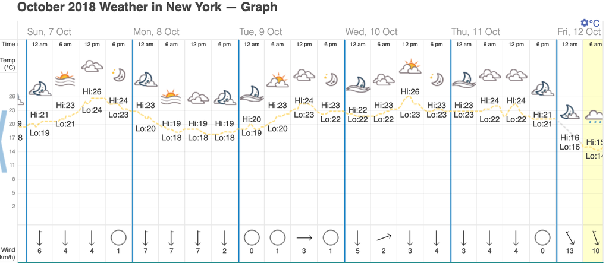

NYC weather in October 2018

*Note how easy it is to insert an image into an RMarkdown document. The syntax is very similar to that for inserting a link – simply add an exclamation mark!*

## Dealing with missing data

Looking at age revealed some missing data. How we deal with missing values depends on what we want to look at. In our case, we probably at least want to get rid of the “?” for age, since it is not clear what it means in comparison to a missing value (“NA”).

To have a look at how many observations have age as ?, we can use `table`. This function is generally useful for counting observations. Note the different usage options.

```r
table(squirrels$age == "?")
```

```
##
## FALSE  TRUE
##  2898     4
```

```r
table(squirrels$age)
```

```
##
##        ?    Adult Juvenile
##        4     2568      330
```

`table` can also be used to count missing values (coded as “NA” in R).

```r
table(is.na(squirrels$age))
```

```
##
## FALSE  TRUE
##  2902   121
```

We can use `filter` to limit our data to only the observations we want to keep. Note this new use of `filter` for cleaning rather than subsetting data.

```r
squirrels_cleaned <- squirrels %>%
  filter(age %in% c(NA, "Adult", "Juvenile"))
```

Let’s look at how this affects our data. Applying the `unique` function to a column yields the unique values in that column. This is very useful for examining which values are present.

```r
unique(squirrels$age)
```

```
## [1] NA         "Adult"    "Juvenile" "?"
```

```r
unique(squirrels_cleaned$age)
```

```
## [1] NA         "Adult"    "Juvenile"
```

### Excursus: the `c` function

What does `c` mean here? `c` is a function which combines elements to form a vector. It can be applied to all sorts of different objects.

```r
c("a","b","c")
```

```
## [1] "a" "b" "c"
```

```r
alphabet <- c("a","b","c")
alphabet
```

```
## [1] "a" "b" "c"
```

```r
c(alphabet,alphabet)
```

```
## [1] "a" "b" "c" "a" "b" "c"
```

## Exercises – part 1

**Exercise 1**. Plot how many squirrels of “Cinnamon” colour were sighted during each AM and PM shift

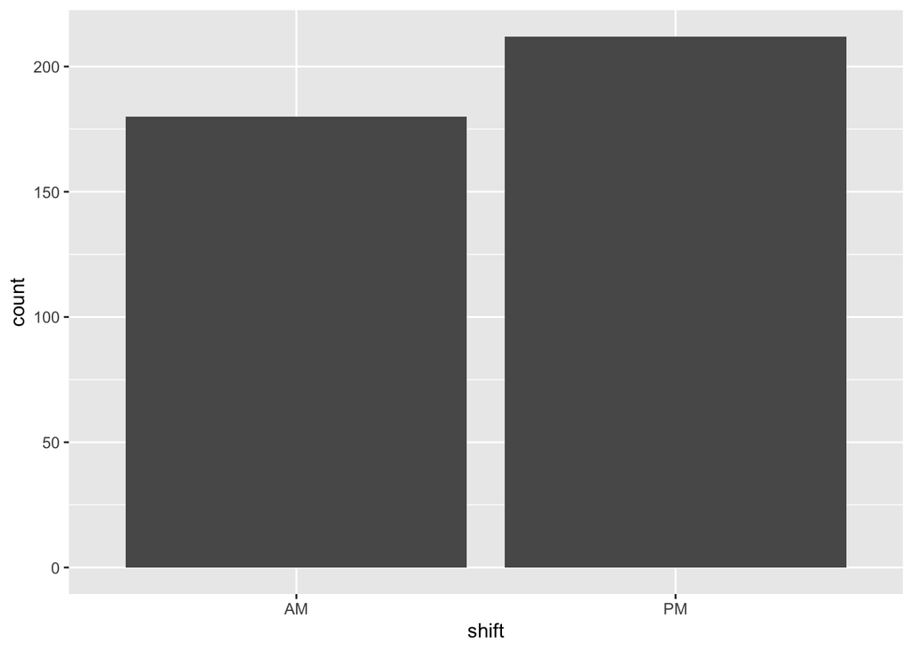

```r
squirrels_cinnamon <- squirrels %>%
  filter(primary_fur_colour == "Cinnamon")

# alternative approach
squirrels_cinnamon2 <- squirrels %>%
  filter(primary_fur_colour %in% c("Cinnamon"))

# simplest approach to plotting counts per shift
ggplot(squirrels_cinnamon,aes(shift)) +
  geom_bar()
```

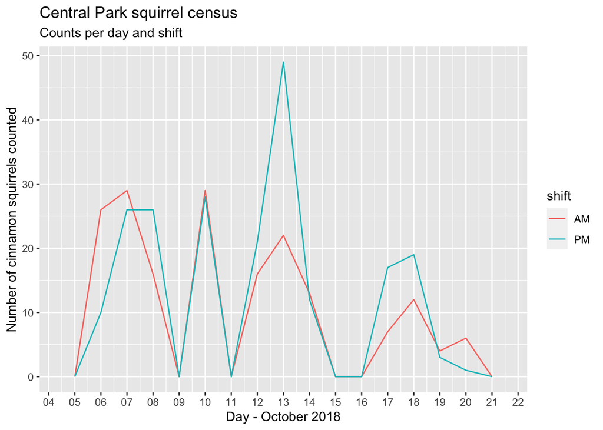

```r
# alternative (and what I was expecting, based on what we were doing above)
# use geom_freqpoly() to plot counts across dates and distinguish shift by colour
ggplot(squirrels_cinnamon, aes(date)) +
  geom_freqpoly(aes(colour = shift), binwidth = 1) +
  scale_x_date(date_breaks = "days" , date_labels = "%d") +
  xlab("Day - October 2018") +
  ylab ("Number of cinnamon squirrels counted") +
  ggtitle("Central Park squirrel census", subtitle = "Counts per day and shift")
```

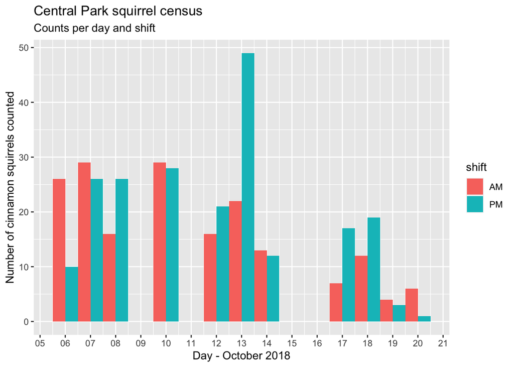

```r
# another alternative using a histogram
# position = "dodge" avoids stacking the bars
ggplot(squirrels_cinnamon, aes(date)) +
  geom_histogram(aes(fill = shift), binwidth = 1, position = "dodge") +
  scale_x_date(date_breaks = "days" , date_labels = "%d") +
  xlab("Day - October 2018") +
  ylab ("Number of cinnamon squirrels counted") +
  ggtitle("Central Park squirrel census", subtitle = "Counts per day and shift")
```

**Exercise 2**. Facet the plot by squirrel age

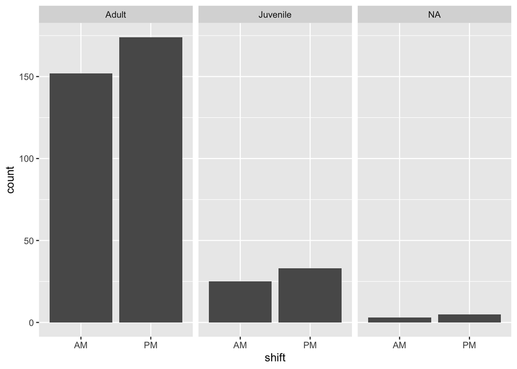

```r
# alternative 1 from above
ggplot(squirrels_cinnamon,aes(shift)) +
  geom_bar() +
  facet_wrap(~age)
```

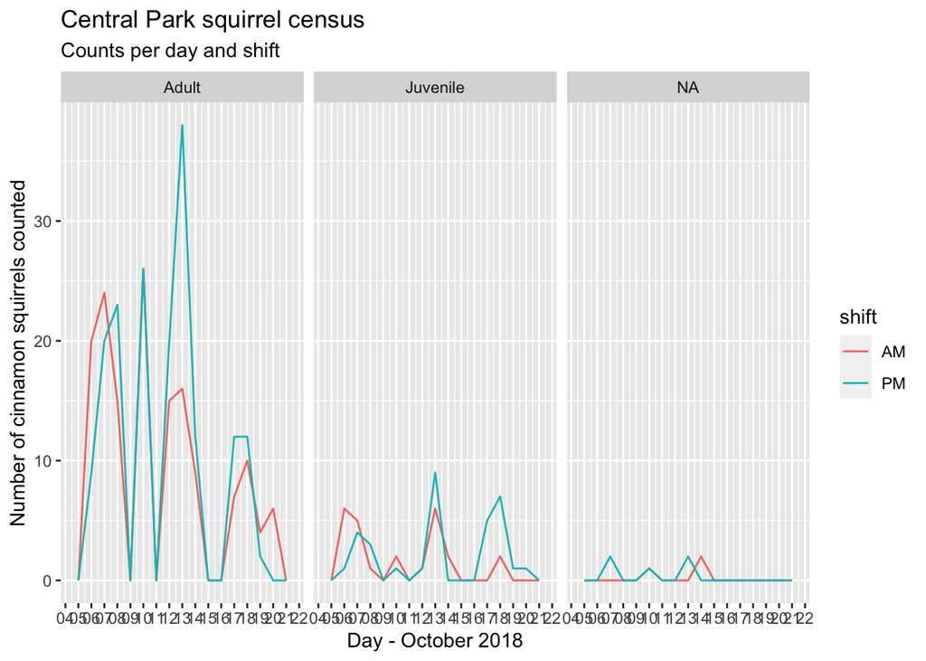

```r
# alternative 2 from above
ggplot(squirrels_cinnamon, aes(date)) +
  geom_freqpoly(aes(colour = shift), binwidth = 1) +
  scale_x_date(date_breaks = "days" , date_labels = "%d") +
  xlab("Day - October 2018") +
  ylab ("Number of cinnamon squirrels counted") +
  ggtitle("Central Park squirrel census", subtitle = "Counts per day and shift") +
  facet_wrap(~age)
```

## Summary statistics using counts

We can use `n` to count the number of observations.

```r
# number of squirrels per shift
squirrels %>%
  group_by(shift) %>%
  summarise(number = n())
```

```
## # A tibble: 2 x 2
##   shift number
## * <chr>  <int>
## 1 AM      1347
## 2 PM      1676
```

```r
# more convenient shorthand
squirrels %>%
  group_by(shift) %>%
  tally()
```

```
## # A tibble: 2 x 2
##   shift     n
## * <chr> <int>
## 1 AM     1347
## 2 PM     1676
```

```r
# and more convenient still
# count combines group_by and tally
squirrels %>%
  count(shift)
```

```
## # A tibble: 2 x 2
##   shift     n
## * <chr> <int>
## 1 AM     1347
## 2 PM     1676
```

```r
# you can also group by multiple variables
squirrels %>%
  count(shift,primary_fur_colour)
```

```
## # A tibble: 8 x 3
##   shift primary_fur_colour     n
##   <chr> <chr>              <int>
## 1 AM    Black                 51
## 2 AM    Cinnamon             180
## 3 AM    Gray                1087
## 4 AM    <NA>                  29
## 5 PM    Black                 52
## 6 PM    Cinnamon             212
## 7 PM    Gray                1386
## 8 PM    <NA>                  26
```

The code below illustrates summarise using the `mean()` and `sd()` (standard deviation) functions with the `gapminder` data.

```r
library(gapminder)

# calculate mean life expectancy per continent in 1952
gapminder %>%
  filter(year == 1952) %>%
  group_by(continent) %>%
  summarise(mean_lifeExp = mean(lifeExp))
```

```
## # A tibble: 5 x 2
##   continent mean_lifeExp
## * <fct>            <dbl>
## 1 Africa            39.1
## 2 Americas          53.3
## 3 Asia              46.3
## 4 Europe            64.4
## 5 Oceania           69.3
```

```r
# calculate sd of expectancy per continent in 1952
gapminder %>%
  filter(year == 1952) %>%
  group_by(continent) %>%
  summarise(sd_lifeExp = sd(lifeExp))
```

```
## # A tibble: 5 x 2
##   continent sd_lifeExp
## * <fct>          <dbl>
## 1 Africa         5.15
## 2 Americas       9.33
## 3 Asia           9.29
## 4 Europe         6.36
## 5 Oceania        0.191
```

```r
# you can also calculate both in one go!
# calculate mean life expectancy per continent in 1952
gapminder %>%
  filter(year == 1952) %>%
  group_by(continent) %>%
  summarise(mean_lifeExp = mean(lifeExp),
            sd_lifeExp = sd(lifeExp))
```

```
## # A tibble: 5 x 3
##   continent mean_lifeExp sd_lifeExp
## * <fct>            <dbl>      <dbl>
## 1 Africa            39.1      5.15
## 2 Americas          53.3      9.33
## 3 Asia              46.3      9.29
## 4 Europe            64.4      6.36
## 5 Oceania           69.3      0.191
```

## Exercises – part 2

**Exercise 3**. Plot the number of black squirrels sighted each day.

```r
count_black <-  squirrels %>%
  filter(primary_fur_colour == "Black") %>%
  count(date)

count_black
```

```
## # A tibble: 11 x 2
##    date           n
##  * <date>     <int>
##  1 2018-10-06    19
##  2 2018-10-07    12
##  3 2018-10-08     7
##  4 2018-10-10     4
##  5 2018-10-12     8
##  6 2018-10-13    15
##  7 2018-10-14    14
##  8 2018-10-17    13
##  9 2018-10-18     5
## 10 2018-10-19     5
## 11 2018-10-20     1
```

```r
# we could also have filtered after counting:
count_by_colour <-  squirrels %>%
  count(primary_fur_colour, date) %>%
  filter(primary_fur_colour == "Black")

count_by_colour
```

```
## # A tibble: 11 x 3
##    primary_fur_colour date           n
##    <chr>              <date>     <int>
##  1 Black              2018-10-06    19
##  2 Black              2018-10-07    12
##  3 Black              2018-10-08     7
##  4 Black              2018-10-10     4
##  5 Black              2018-10-12     8
##  6 Black              2018-10-13    15
##  7 Black              2018-10-14    14
##  8 Black              2018-10-17    13
##  9 Black              2018-10-18     5
## 10 Black              2018-10-19     5
## 11 Black              2018-10-20     1
```

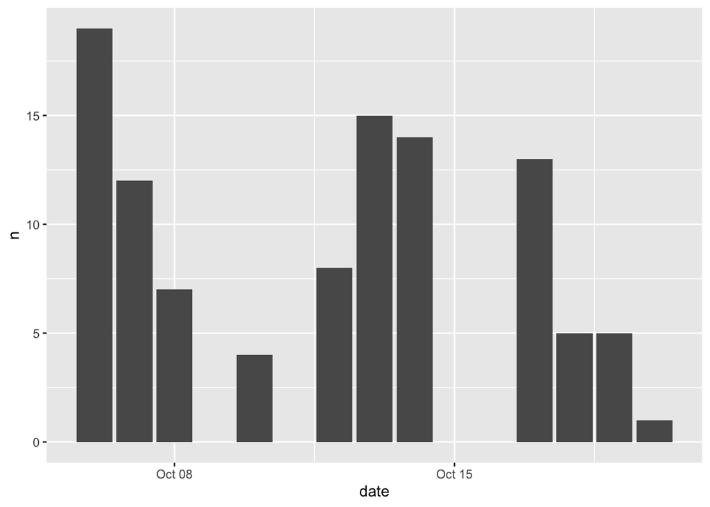

```r
ggplot(count_by_colour,aes(date,n)) +
  geom_col()
```

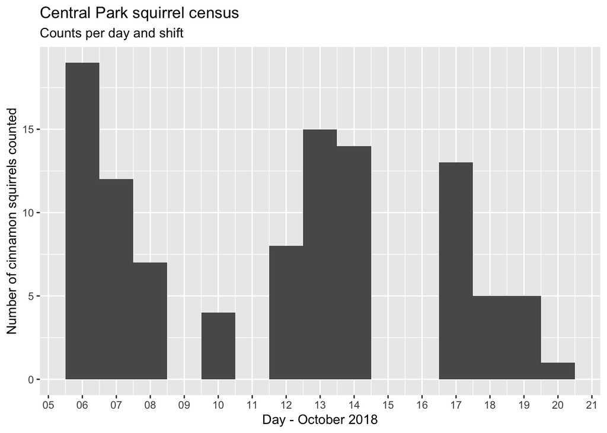

```r
# alternative without using count()
# note that the intention of the exercise was to count first and then plot
# However, given the phrasing of the question, it was also perfectly legitimate to get geom_histogram() or geom_freqpoly() to count for you!
# In this case, you only need to filter before plotting

squirrels_black <- squirrels %>%
  filter(primary_fur_colour == "Black")

ggplot(squirrels_black, aes(date)) +
  geom_histogram(binwidth = 1) +
  scale_x_date(date_breaks = "days" , date_labels = "%d") +
  xlab("Day - October 2018") +
  ylab ("Number of cinnamon squirrels counted") +
  ggtitle("Central Park squirrel census", subtitle = "Counts per day and shift")
```

## Boxplots

Finally, let’s summarise the data using box-and-whiskers plots. Can you recall what a boxplot shows?

First, we need a data set with counts. We choose to group these by a number of variables. `na.omit` eliminates missing values.

```r
squirrels_age_colour <- squirrels_cleaned %>%
  count(shift,age,primary_fur_colour,date) %>%
  na.omit()
```

Summarise using boxplots:

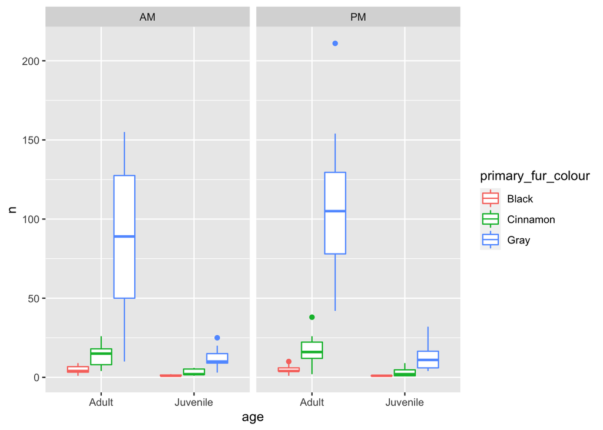

```r
ggplot(squirrels_age_colour, aes(age, n)) +
  geom_boxplot(aes(colour = primary_fur_colour)) +
  facet_wrap(~ shift)
```

## Exercises – part 3

**Exercise 4**. The variables `Approaches`, `Indifferent` and `Runs from` describe how the observed squirrels interacted with humans. (Note that you will need to go back to the original data set to access these variables!)

1. What are the possible values for these variables?
2. How many squirrels were observed displaying each of the the three behaviours?
3. Does squirrel behaviour differ depending on age or shift? Create boxplots to examine this question. (This one is a challenge!)

```r
# first: read in the data again
squirrels2 <- read_csv("data/2018_Central_Park_Squirrel_Census_-_Squirrel_Data.csv")
# Answer a: TRUE / FALSE (can be seen either by examining the data or via the type of variable in
#           tibble summary: "lgl" = "logical")

# preparation for the remaining questions
# select columns of interest and rename
squirrels2_sel <- squirrels2 %>%
  rename(Runs_from = `Runs from`) %>%
  mutate(Date = mdy(Date)) %>%
  select(Date, Shift, Age, Approaches, Indifferent, Runs_from)


# Answer b: this can be done using both count and tally
#           the output is slightly different for each one

squirrels2_sel %>%
  count(Approaches)
```

```
## # A tibble: 2 x 2
##   Approaches     n
## * <lgl>      <int>
## 1 FALSE       2845
## 2 TRUE         178
```

```r
squirrels2_sel %>%
  tally(Runs_from)
```

```
## # A tibble: 1 x 1
##       n
##   <int>
## 1   678
```

```r
squirrels2_sel %>%
  tally(Indifferent)
```

```
## # A tibble: 1 x 1
##       n
##   <int>
## 1  1454
```

```r
# you could also use table(), e.g.
table(squirrels2_sel$Approaches)
```

```
##
## FALSE  TRUE
##  2845   178
```

```r
# finally, note that count() can also be used to cross-tabulate the behaviours
squirrels2_sel %>%
  count(Approaches,Indifferent,Runs_from)
```

```
## # A tibble: 8 x 4
##   Approaches Indifferent Runs_from     n
##   <lgl>      <lgl>       <lgl>     <int>
## 1 FALSE      FALSE       FALSE       780
## 2 FALSE      FALSE       TRUE        630
## 3 FALSE      TRUE        FALSE      1407
## 4 FALSE      TRUE        TRUE         28
## 5 TRUE       FALSE       FALSE       143
## 6 TRUE       FALSE       TRUE         16
## 7 TRUE       TRUE        FALSE        15
## 8 TRUE       TRUE        TRUE          4
```

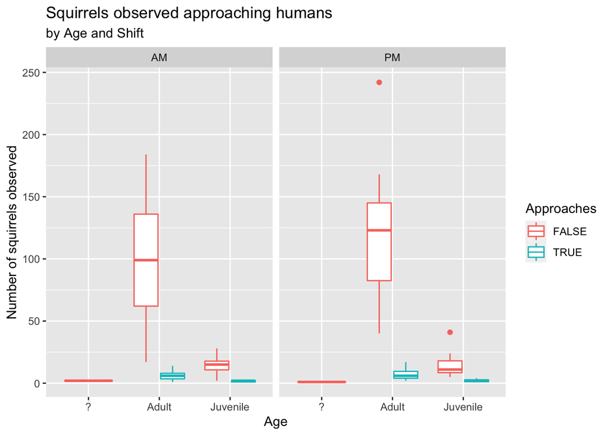

```r
# Answer c:
approach <- squirrels2_sel %>%
  # key here is in the inclusion of Date
  # to allow for enough variability to create the boxplots
  count(Approaches,Age,Shift, Date) %>%
  # note that this only removes the missing values
  # we might also want to remove the ? entries as above
  na.omit()

ggplot(approach, aes(x = Age, y = n)) +
  geom_boxplot(aes(colour = Approaches)) +
  facet_wrap(~ Shift) +
  ggtitle("Squirrels observed approaching humans", subtitle = "by Age and Shift") +
  ylab("Number of squirrels observed")
```

```r
# Note: this is only one way of tackling this problem.
```